# NYPD Shooting Incident Data Report

Tina L.

2024-06-22

## Project File

This project file will analyze NYPD Shooting Incident Data (Historic), which can be exported from the website: https://catalog.data.gov/dataset/nypd-shooting-incident-data-historic

The data lists every shooting incident that happened in the city of New York going back to 2006 through the end of the previous calendar year.

The data was last updated on April 25, 2024 by NYC OpenData. Each record represents a shooting incident in the city of New York and includes information about the incident, such as the location and time. Information pertaining to the suspects and the victims are included. This data is available to the public.

## Importing Data

Download the data from the catalog.data.gov website as a csv file. Save the CSV in your working directory and use the read_csv function to load the data into R. We will load the library tidyverse which is an R package that helps to transform and tidy data.

```r
library(tidyverse)
```

```r
data <- read_csv('NYPD_Shooting_Incident_Data__Historic_.csv')
```

## Tidying and Transforming Data

After importing the data, we will ensure that the data has the correct data type and in the right format.

Check the data type of each column of the project file.

```r
spec(data)
```

Many of the data columns defined as character can be re-defined as categorical variables.

```r
#converting categorical variables to character data type
data <- data%>%
  mutate(BORO = as.factor(BORO),
         PERP_AGE_GROUP = as.factor(PERP_AGE_GROUP),
         PERP_SEX = as.factor(PERP_SEX),
         PERP_RACE = as.factor(PERP_RACE),
         PERP_AGE_GROUP = as.factor(PERP_AGE_GROUP),
         VIC_AGE_GROUP = as.factor(VIC_AGE_GROUP),
         VIC_SEX = as.factor(VIC_SEX),
         VIC_RACE = as.factor(VIC_RACE)
        )

summary(data)
```

```
##   INCIDENT_KEY        OCCUR_DATE         OCCUR_TIME                  BORO
##  Min.   :  9953245   Length:28562       Length:28562      BRONX        : 8376
##  1st Qu.: 65439914   Class :character   Class1:hms        BROOKLYN     :11346
##  Median : 92711254   Mode  :character   Class2:difftime   MANHATTAN    : 3762
##  Mean   :127405824                      Mode  :numeric    QUEENS       : 4271
##  3rd Qu.:203131993                                        STATEN ISLAND:  807
##  Max.   :279758069
##
##  LOC_OF_OCCUR_DESC     PRECINCT     JURISDICTION_CODE LOC_CLASSFCTN_DESC
##  Length:28562       Min.   :  1.0   Min.   :0.0000    Length:28562
##  Class :character   1st Qu.: 44.0   1st Qu.:0.0000    Class :character
##  Mode  :character   Median : 67.0   Median :0.0000    Mode  :character
##                     Mean   : 65.5   Mean   :0.3219
##                     3rd Qu.: 81.0   3rd Qu.:0.0000
##                     Max.   :123.0   Max.   :2.0000
##                                     NA's   :2
##  LOCATION_DESC      STATISTICAL_MURDER_FLAG PERP_AGE_GROUP   PERP_SEX
##  Length:28562       Mode :logical           18-24  :6438   (null): 1141
##  Class :character   FALSE:23036             25-44  :6041   F     :  444
##  Mode  :character   TRUE :5526              UNKNOWN:3148   M     :16168
##                                             <18    :1682   U     : 1499
##                                             (null) :1141   NA's  : 9310
##                                             (Other): 768
##                                             NA's   :9344
##           PERP_RACE     VIC_AGE_GROUP   VIC_SEX
##  BLACK         :11903   <18    : 2954   F: 2760
##  WHITE HISPANIC: 2510   1022   :    1   M:25790
##  UNKNOWN       : 1837   18-24  :10384   U:   12
##  BLACK HISPANIC: 1392   25-44  :12973
##  (null)        : 1141   45-64  : 1981
##  (Other)       :  469   65+    :  205
##  NA's          : 9310   UNKNOWN:   64
##                            VIC_RACE       X_COORD_CD        Y_COORD_CD
##  AMERICAN INDIAN/ALASKAN NATIVE:   11   Min.   : 914928   Min.   :125757
##  ASIAN / PACIFIC ISLANDER      :  440   1st Qu.:1000068   1st Qu.:182912
##  BLACK                         :20235   Median :1007772   Median :194901
##  BLACK HISPANIC                : 2795   Mean   :1009424   Mean   :208380
##  UNKNOWN                       :   70   3rd Qu.:1016807   3rd Qu.:239814
##  WHITE                         :  728   Max.   :1066815   Max.   :271128
##  WHITE HISPANIC                : 4283
##     Latitude       Longitude        Lon_Lat
##  Min.   :40.51   Min.   :-74.25   Length:28562
##  1st Qu.:40.67   1st Qu.:-73.94   Class :character
##  Median :40.70   Median :-73.92   Mode  :character
##  Mean   :40.74   Mean   :-73.91
##  3rd Qu.:40.82   3rd Qu.:-73.88
##  Max.   :40.91   Max.   :-73.70
##  NA's   :59      NA's   :59
```

The OCCUR_DATE data type is String. It should be converted to DATE.

```r
data <- data%>%
  mutate(OCCUR_DATE = as.Date(OCCUR_DATE, "%m/%d/%y"))
```

Check if the data structure has the correct data type.

```r
#get structure of data
str(data)
```

```
## tibble [28,562 × 21] (S3: tbl_df/tbl/data.frame)
##  $ INCIDENT_KEY           : num [1:28562] 2.45e+08 2.48e+08 8.50e+07 2.03e+08 2.71e+07 ...
##  $ OCCUR_DATE             : Date[1:28562], format: "2020-05-05" "2020-07-04" ...
##  $ OCCUR_TIME             : 'hms' num [1:28562] 00:10:00 22:20:00 19:35:00 21:00:00 ...
##   ..- attr(*, "units")= chr "secs"
##  $ BORO                   : Factor w/ 5 levels "BRONX","BROOKLYN",..: 3 1 4 1 2 3 4 2 1 1 ...
##  $ LOC_OF_OCCUR_DESC      : chr [1:28562] "INSIDE" "OUTSIDE" NA NA ...
##  $ PRECINCT               : num [1:28562] 14 48 103 42 83 23 113 77 48 49 ...
##  $ JURISDICTION_CODE      : num [1:28562] 0 0 0 0 0 2 0 0 0 0 ...
##  $ LOC_CLASSFCTN_DESC     : chr [1:28562] "COMMERCIAL" "STREET" NA NA ...
##  $ LOCATION_DESC          : chr [1:28562] "VIDEO STORE" "(null)" NA NA ...
##  $ STATISTICAL_MURDER_FLAG: logi [1:28562] TRUE TRUE FALSE FALSE FALSE FALSE ...
##  $ PERP_AGE_GROUP         : Factor w/ 11 levels "(null)","<18",..: 7 1 NA 7 7 NA NA NA NA 7 ...
##  $ PERP_SEX               : Factor w/ 4 levels "(null)","F","M",..: 3 1 NA 3 3 NA NA NA NA 3 ...
##  $ PERP_RACE              : Factor w/ 8 levels "(null)","AMERICAN INDIAN/ALASKAN NATIVE",..: 4 1 NA 6 4 NA NA NA NA 8 ...
##  $ VIC_AGE_GROUP          : Factor w/ 7 levels "<18","1022","18-24",..: 4 3 3 4 4 4 5 4 3 4 ...
##  $ VIC_SEX                : Factor w/ 3 levels "F","M","U": 2 2 2 2 2 2 2 2 2 2 ...
##  $ VIC_RACE               : Factor w/ 7 levels "AMERICAN INDIAN/ALASKAN NATIVE",..: 3 3 3 3 3 3 3 3 3 3 ...
##  $ X_COORD_CD             : num [1:28562] 986050 1016802 1048632 1014493 1009149 ...
##  $ Y_COORD_CD             : num [1:28562] 214231 250581 198262 242565 190105 ...
##  $ Latitude               : num [1:28562] 40.8 40.9 40.7 40.8 40.7 ...
##  $ Longitude              : num [1:28562] -74 -73.9 -73.8 -73.9 -73.9 ...
##  $ Lon_Lat                : chr [1:28562] "POINT (-73.9935 40.754692)" "POINT (-73.88233 40.854402)" "POINT (-73.76777349199995 40.71063412500007)" "POINT (-73.89071440599997 40.832416753000075)" ...
```

When analyzing the different sub-groups for VIC_AGE_GROUP, there is one response saying their age group is 1022. This does not seem right as no one in the world can live up to the age of 1022. Therefore, convert this response to ‘unknown’.

```r
unique(data$VIC_AGE_GROUP)
```

```
## [1] 25-44   18-24   45-64   65+     <18     UNKNOWN 1022
## Levels: <18 1022 18-24 25-44 45-64 65+ UNKNOWN
```

```r
table(data$VIC_AGE_GROUP)
```

```
##
##     <18    1022   18-24   25-44   45-64     65+ UNKNOWN
##    2954       1   10384   12973    1981     205      64
```

```r
data['VIC_AGE_GROUP'][data['VIC_AGE_GROUP'] == '1022'] <- 'UNKNOWN'
```

Similar to VIC_AGE_GROUP, PERP_AGE_GROUP has responses with age group include 1020,1028,224, and 940. This does not seem right as no one in the world can live up to these ages. Therefore, convert this responses to ‘unknown’.

```r
table(data$PERP_AGE_GROUP)
```

```
##
##  (null)     <18    1020    1028   18-24     224   25-44   45-64     65+     940
##    1141    1682       1       1    6438       1    6041     699      65       1
## UNKNOWN
##    3148
```

```r
data['PERP_AGE_GROUP'][data['PERP_AGE_GROUP'] == '1020'] <- 'UNKNOWN'
data['PERP_AGE_GROUP'][data['PERP_AGE_GROUP'] == '1028'] <- 'UNKNOWN'
data['PERP_AGE_GROUP'][data['PERP_AGE_GROUP'] == '224'] <- 'UNKNOWN'
data['PERP_AGE_GROUP'][data['PERP_AGE_GROUP'] == '940'] <- 'UNKNOWN'
```

Check for null values. Many variables pertaining to the suspect or the location has missing values. Variables regarding the victims and boroughs contains no missing data, therefore we can focus our analysis on the completed information provided.

```r
#checking for missing values
colSums(is.na(data))
```

```
##            INCIDENT_KEY              OCCUR_DATE              OCCUR_TIME
##                       0                       0                       0
##                    BORO       LOC_OF_OCCUR_DESC                PRECINCT
##                       0                   25596                       0
##       JURISDICTION_CODE      LOC_CLASSFCTN_DESC           LOCATION_DESC
##                       2                   25596                   14977
## STATISTICAL_MURDER_FLAG          PERP_AGE_GROUP                PERP_SEX
##                       0                    9344                    9310
##               PERP_RACE           VIC_AGE_GROUP                 VIC_SEX
##                    9310                       0                       0
##                VIC_RACE              X_COORD_CD              Y_COORD_CD
##                       0                       0                       0
##                Latitude               Longitude                 Lon_Lat
##                      59                      59                      59
```

## Visualizing and Analyzing Data

After cleaning the data, we can now use the data to visualize.

Let us check how many incidents there are by each borough. By looking at the graph below, we can identify that Brooklyn has the most incidents, with Staten Island having the least.

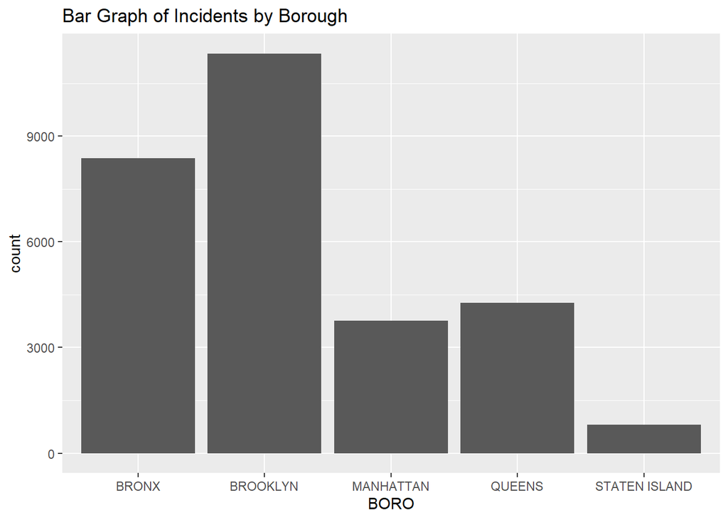

```r
#bar graph of incidents by Borough
ggplot(data, aes(x =BORO)) +
  geom_bar(position = "dodge") +
  labs(title = "Bar Graph of Incidents by Borough")
```

By graphing the incidencse from the project file by victim’s race, we can conclude that the black are mostly targeted.

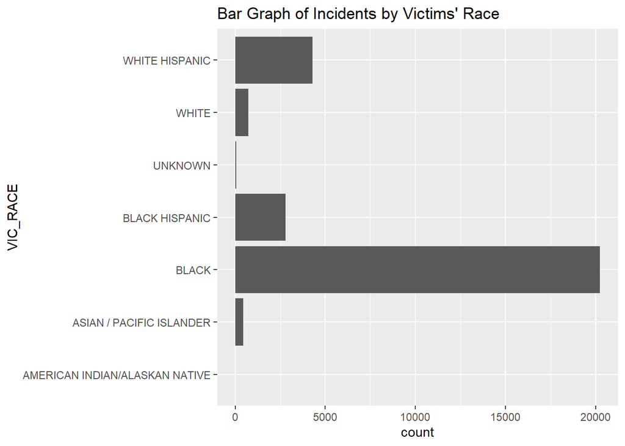

```r
#bar graph of incidents by victim's race
ggplot(data, aes(x =VIC_RACE)) +
    geom_bar() +
    coord_flip() +
    labs(title = "Bar Graph of Incidents by Victims' Race")
```

The graph below displays the number of incidents for each victim age group and sectioned by the victim’s sex.

By glancing at this graph, we can see that male are dominantly the victims, and that males in the age group 25-44 are heavily targeted.

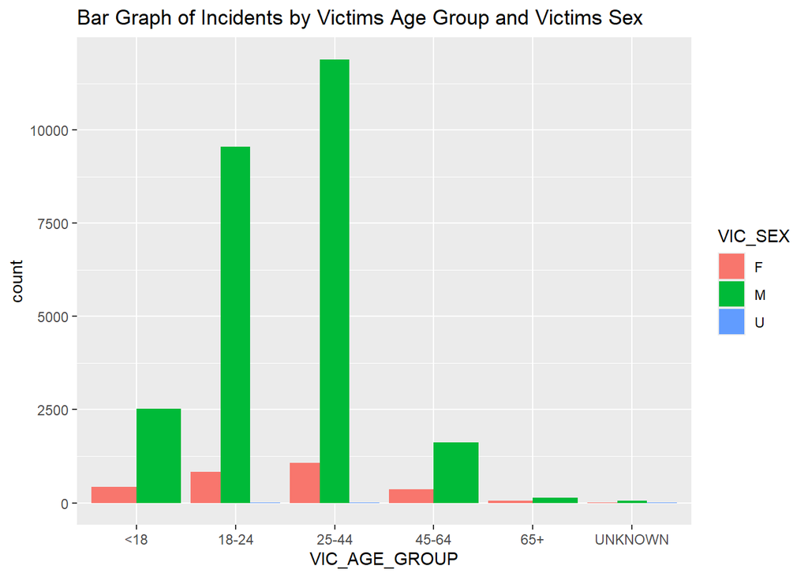

```r
ggplot(data, aes(x =VIC_AGE_GROUP, fill = VIC_SEX)) +
         geom_bar(position = "dodge") +
         labs(title = "Bar Graph of Incidents by Victims Age Group and Victims Sex")
```

By graphing the victim age group and analyzing it with statistical murder flag, it shows that since those in age 25-44 are the most targeted, there are more murder instances in this age group.

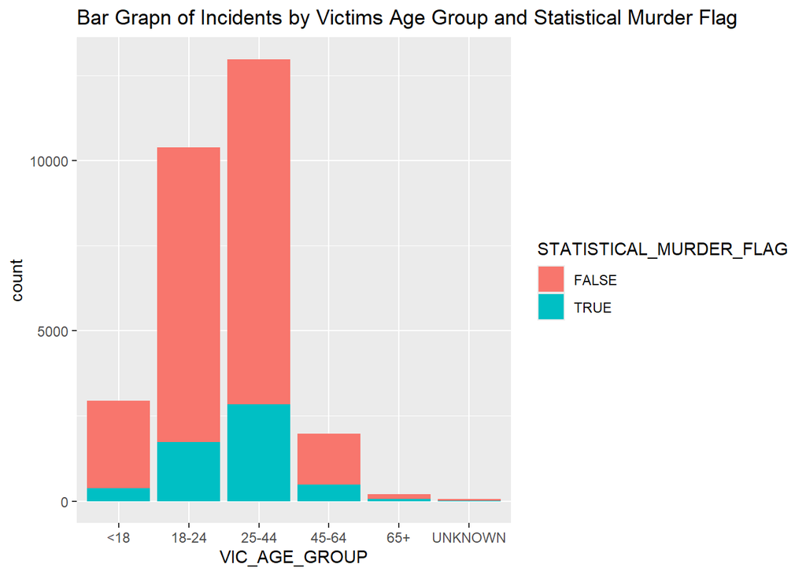

```r
ggplot(data, aes(x =VIC_AGE_GROUP, fill = STATISTICAL_MURDER_FLAG)) +
         geom_bar() +
         labs(title = "Bar Grapn of Incidents by Victims Age Group and Statistical Murder Flag")
```

We can run a chi square test. Chi square test are used for two categorical variables to check association between VIC_AGE_GROUP and VIC_SEX. By looking at the result of the chi square test, the p value is less than 0.5. which means there is significant association between VIC_AGE_GROUP AND VIC_SEX.

```r
chi <- chisq.test(data$VIC_AGE_GROUP, data$VIC_SEX)
chi
```

```
##
##  Pearson's Chi-squared test
##
## data:  data$VIC_AGE_GROUP and data$VIC_SEX
## X-squared = 1732.8, df = 10, p-value < 2.2e-16
```

## Bias Identification

When analyzing data, it is important to recognize that bias can skew the results and analysis. Bias is defined as the prejudice in favor or against someone, a person or a group compared with another in a way that it can be seen as unfair.

Below are the potential bias for this data analysis.

1. Selection Bias  
   Only incidents that are reported are recorded in this project file. There can be incidents that are not in this data and analysis, leading to possible skewed results.
2. Reporting Bias  
   The officers may have bias when reporting the incidents. For example, the suspect’s age or race could be recorded with bias, such as filling out the incidents based on their perception, which may be incorrect.
3. Measurement Bias  
   There can be incorrect recording of where location, coordinates, statistical murder is reported.
4. Social Bias  
   When analyzing the data, it is apparent that there is a social bias that the black are mainly involved in the shootings as the suspect and the victim. When reporting the incidents, the police or reporter may have an assumption on supsects’ or victims’ race.
5. Detection Bias  
   When reporting the incidents, there can be detection bias, such as identifying the suspect incorrectly by age, gender, or race. There can also be detection bias in identifying the victims as well.